# The Effect of Discounts on Retail Sales

# RO3 — Luis Berumen

# RO4 — Tim Arana

# RO5 — Mickyas Shawel

## RO5: Does Marketing Spend Strengthen Discount Performance?

**Analytics Objective:** Analyze whether marketing spend strengthens the relationship between discount percentage and sales performance.

**Business question:**

> Are discounts more effective when they are supported by higher marketing spend?

**Why it matters:** Discounts can only influence customers if customers know about them. Marketing spend may increase awareness of promotions and help convert discount strategy into stronger sales revenue.

**Variables used:**

- **IV 1:** Discount Percentage
- **IV 2:** Marketing Spend
- **Interaction:** Discount % × Marketing Spend
- **Primary DV:** Sales Revenue
- **Secondary DV:** Units Sold

## RO5: Wrangling Plan

**Data preparation steps:**

1. Use cleaned retail records from 2022–2024
2. Group discounts into no, low, and high levels
3. Split marketing spend into low, medium, and high groups
4. Create an interaction feature: `discount_pct * mktg_spend`
5. Summarize revenue and units by discount group and marketing spend group

RO5 Summary by Discount and Marketing Spend

| discount_group | mktg_spend_group | transactions | avg_revenue | avg_units | avg_mktg_spend |
| --- | --- | --- | --- | --- | --- |
| No Discount | Low Marketing Spend | 7616 | $2,825.32 | 6.1 | $0.00 |
| No Discount | Medium Marketing Spend | 7624 | $2,858.60 | 6.2 | $16.68 |
| No Discount | High Marketing Spend | 7606 | $2,820.62 | 6.2 | $133.16 |
| Low (1-10%) | Low Marketing Spend | 1169 | $2,590.45 | 6.0 | $0.00 |
| Low (1-10%) | Medium Marketing Spend | 1241 | $2,624.39 | 6.2 | $16.70 |
| Low (1-10%) | High Marketing Spend | 1198 | $2,583.73 | 6.2 | $132.44 |
| High (11-20%) | Low Marketing Spend | 1215 | $2,294.26 | 6.1 | $0.00 |
| High (11-20%) | Medium Marketing Spend | 1135 | $2,339.43 | 6.2 | $16.82 |
| High (11-20%) | High Marketing Spend | 1196 | $2,422.09 | 6.2 | $133.68 |

## RO5: Marketing Spend and Revenue

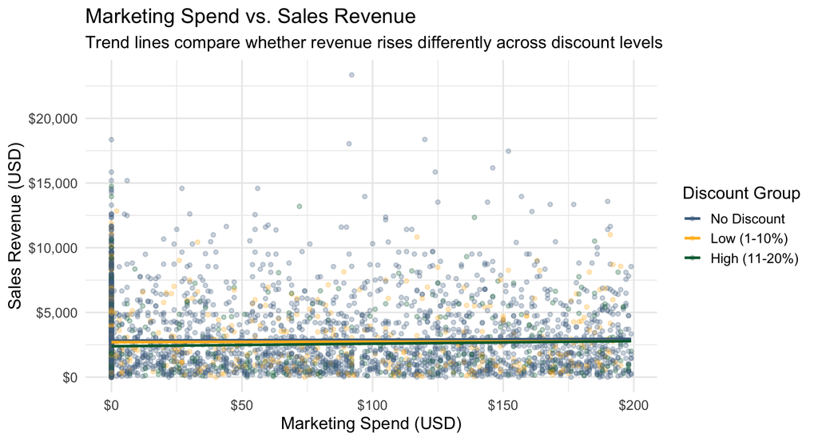